# MECH481A6: Engineering Data Analysis in R

Chapter 5 Homework: Exploring Univariate Data

Vance Petersen

07 October, 2025

# Grading

We will grade the **knitted** PDF or HTML document from within your private GitHub repository. Remember to make regular, small commits (e.g., at least one commit per question) to save your work. We will grade the latest knit, as long as it occurs *before* the start of the class in which we advance to the next chapter. As always, reach out with questions via GitHub Issues or during office hours.

# Data

You are probably sick of seeing the ozone data, but there’s still more to do with the file. Ozone concentration measurement is considered univariate, thus we can use basic exploratory data analysis approaches to examine the data.

# Preparation

Load the necessary R packages into your R session.

Recreate the pipe of `dplyr` functions that you used to import the data, select and rename the variables listed below, drop missing observations, and assign the output with a good name.

- `sample_measurement` renamed as `ozone_ppm` (ozone measurement in ppm)
- `datetime` (date in YYYY-MM-DD format and time of measurement in HH:MM:SS)

Check that the data imported correctly.

```
## # A tibble: 16,914 × 2
##    ozone_ppm datetime
##        <dbl> <dttm>
##  1     0.017 2019-01-01 07:00:00
##  2     0.017 2019-01-01 08:00:00
##  3     0.017 2019-01-01 09:00:00
##  4     0.017 2019-01-01 10:00:00
##  5     0.015 2019-01-01 11:00:00
##  6     0.017 2019-01-01 12:00:00
##  7     0.028 2019-01-01 13:00:00
##  8     0.03  2019-01-01 14:00:00
##  9     0.036 2019-01-01 15:00:00
## 10     0.036 2019-01-01 16:00:00
## # ℹ 16,904 more rows
```

# Chapter 5 Homework: Exploring Univariate Data

## Question 1: Definitions

Guess the location, dispersion, and shape of ozone concentration data, based on the definitions of each described in the coursebook. No code needed; just use your intuition. For shape, take a look at the coursebook appendix on reference distributions.

- location: values tend to be smaller as ozone concentration is measured in parts per million. I would assume the central tendency to be slight but I’m not sure where it would show up
- dispersion: The values would likely stay quite similar to each other from one observation to the next
- shape: The ozone values are most likely cyclic

## Question 2: Quartiles

Calculate the quartiles of `ozone_ppm`. What is the minimum? Maximum? Median?

```
##    ozone_ppm          datetime
##  Min.   :0.00000   Min.   :2019-01-01 07:00:00
##  1st Qu.:0.02300   1st Qu.:2019-03-30 21:00:00
##  Median :0.03300   Median :2019-06-27 12:30:00
##  Mean   :0.03305   Mean   :2019-07-01 06:37:00
##  3rd Qu.:0.04300   3rd Qu.:2019-10-03 22:45:00
##  Max.   :0.09600   Max.   :2020-01-01 06:00:00
```

### Extra Credit

Create [a similar table](https://smogdr.github.io/edar_coursebook/eda1.html#descriptive-statistics) for `ozone_ppm`. Hint: You will need to investigate table options in the `knitr` package.

## Question 3: Cumulative Distribution Plot

Using either relevant `ggplot2` `geom` option, create a cumulative distribution plot of `ozone_ppm`. Tweak the axis ranges for optimal data representation, using `scale_*_continuous()` with `breaks =` and `minor_breaks =` arguments. Add axis labels, title, subtitle, and theme.

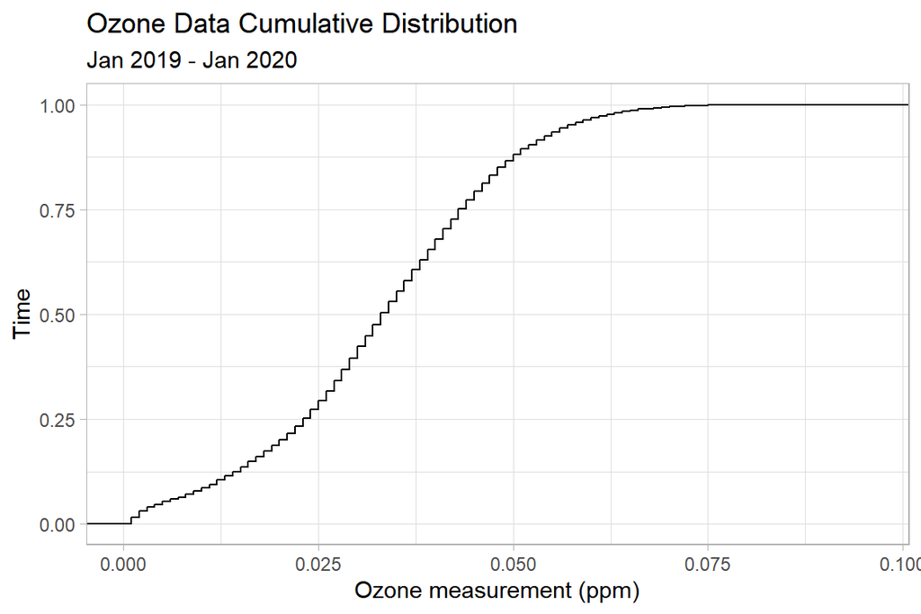

## Question 4: Histogram

Create a histogram of `ozone_ppm`. Within the `geom`, mess with the number of bins (e.g., 20, 50, 75, 100, 200) to explore the true shape and granularity of the data. Match the plot style (e.g., title, subtitle, axis labels, theme) you chose in Question 3, with the relevant adjustments such as “Histogram” instead of “Cumulative Distribution Plot”.

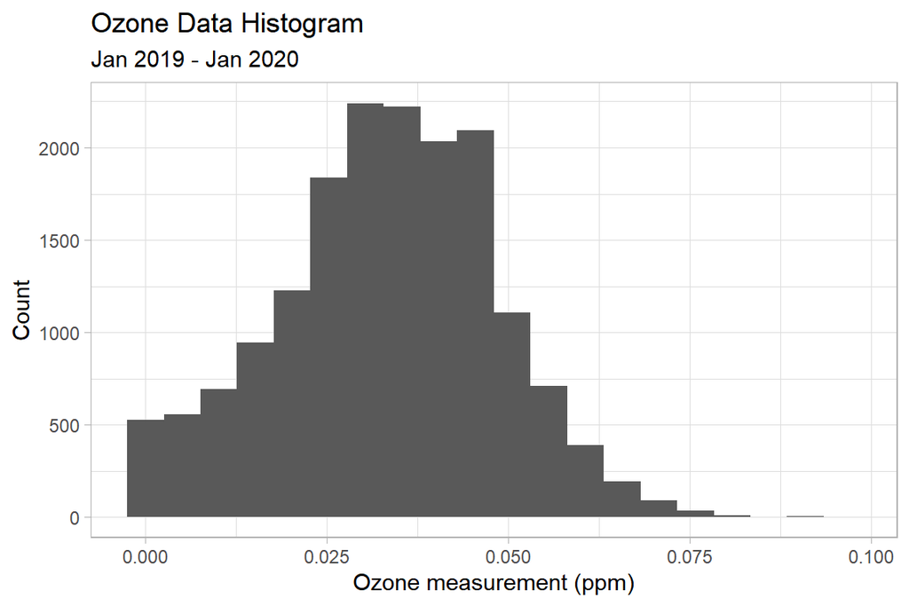

### Question 5: Concept

What mathematical concept is a histogram (Q4) attempting to visualize?

- The central tendency or frequency distribution of the data

### Question 6: Distribution

Based on the histogram (Q4), does ozone concentration appear to be normally distributed?

- It does not. There is a central tendency around 0.035 ppm

### Question 7: Outliers

Based on the histogram (Q4), do you see any possible outliers? Skewness? How might this affect the spread and central tendency?

## Question 8: Boxplot

Generate a boxplot of ozone concentration on the y-axis with a title, subtitle, y-axis label, and theme consistent with the style of the previous two plots. Use quotes (`""`) as the `x` arguments within the calls to the aesthetic and labels to remove the x-axis scale and label.

[figure not shown]

# Subset Data

Use the following code to create a dataframe for use in the remaining questions. These ozone concentration measurements were taken on July 4, 2019 in Fort Collins, CO. This code detects certain characters with the `datetime` object and filters to observations containing those characters. There are other ways this could have been done (e.g., `dplyr::filter()` with `%in%` operator).

## Question 9: Autocorrelation Plot

Define autocorrelation as it relates to ozone concentration measurement.

Create an autocorrelation plot of ozone concentration, using `stats::acf()` and include axis labels and title. Describe what you see based on the features of interest outlined in the coursebook.

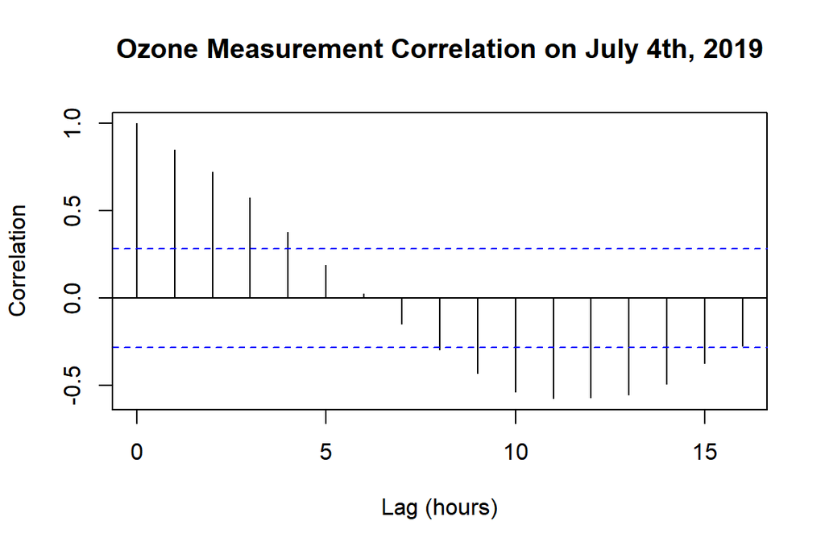

## Question 10: Parial Autocorrelation Plot

Define partial autocorrelation as it relates to ozone concentration measurement.

- Partial autocorrelation would be how dependent the ozone measurements are upon each other while not considering intermediate measurements

Now create a partial autocorrelation plot of day ozone concentration with axis labels. Describe what you see. How does this compare to the autocorrelation plot in the previous question?

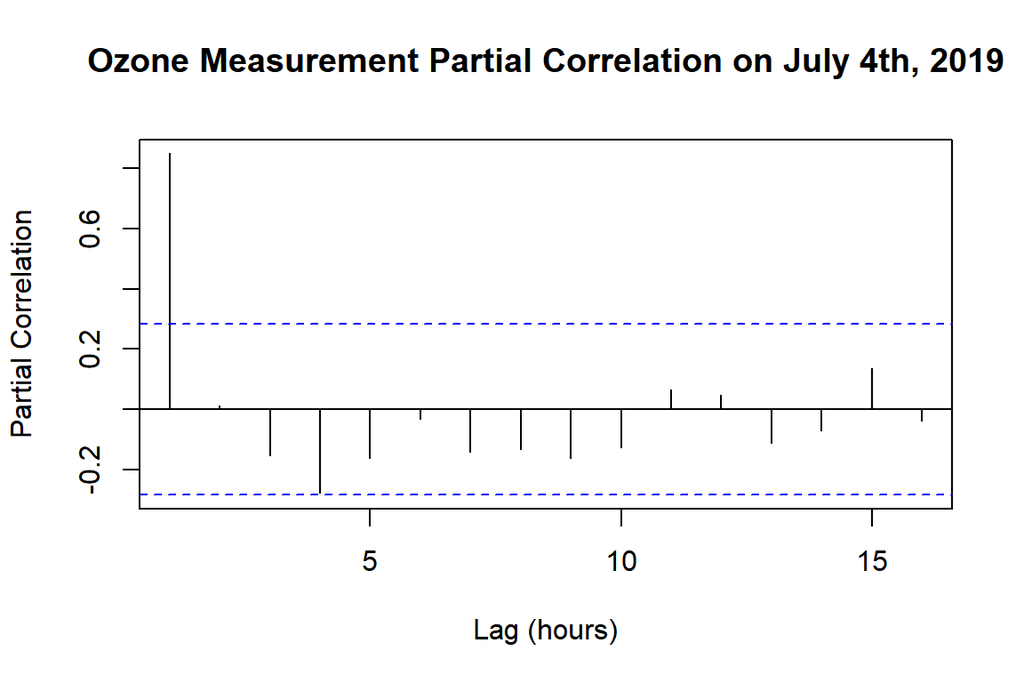

- The main difference between the two graphs is that most values are on the negative side of the partial correlation plot, and within the blue lines. the plot also does not appear to be a 12 hour cycle.
- This means that most data points have little correlation with each other, and alternate up and down

# Appendix

```r
# set global options for figures, code, warnings, and messages
knitr::opts_chunk$set(fig.width = 6, fig.height = 4, fig.path = "../figs/",
                      echo = FALSE, warning = FALSE, message = FALSE)
# load packages
library("dplyr")
library("ggplot2")
library("readr")
library("knitr")
library("kableExtra")
# ozone: import, select, drop missing observations, rename
ppm_and_time <- read_csv("C:/Users/Vance/OneDrive - Colostate/Desktop/Petersen---MECH476/data/ftc_o3.csv") %>% dplyr::select(sample_measurement, datetime) %>% filter(!is.na(sample_measurement), !is.na(datetime)) %>% rename(ozone_ppm = sample_measurement)
# examine dataframe object
ppm_and_time
# calculate quantiles of ozone concentration
summary(ppm_and_time)
#summary(ppm) %>% kbl() %>% kable_material(c("striped", "hover"))
# plot cumulative distribution of ozone concentration
ppm_and_time %>% ggplot(aes(x = ozone_ppm)) + stat_ecdf() + labs(x = "Ozone measurement (ppm)", y = "Time") + theme_light() + labs(title = "Ozone Data Cumulative Distribution", subtitle = "Jan 2019 - Jan 2020")
# create histogram of ozone concentration
ppm_and_time %>% ggplot(aes(x = ozone_ppm)) + geom_histogram(bins = 20) + labs(x = "Ozone measurement (ppm)", y = "Count") + theme_light() + labs(title = "Ozone Data Histogram", subtitle = "Jan 2019 - Jan 2020")
# create ozone boxplot

ppm_and_time %>% ggplot(aes(x = "", y = datetime)) + geom_boxplot() + labs(x = "", y = "Count") + theme_light() + labs(title = "Ozone Data Boxplot", subtitle = "Jan 2019 - Jan 2020")

# create subset of data with only one day to examine daily pattern
# I did not ask you to code this because we have not discussed dates or stringr
# You need to uncomment the below three lines and run it; check object names
ozone_day <- ppm_and_time %>%
dplyr::filter(stringr::str_detect(string = datetime, pattern = "2019-07-04"))
# create autocorrelation plot with ozone_day df
stats::acf(ozone_day$ozone_ppm, xlab = "Lag (hours)", ylab = "Correlation", main = "Ozone Measurement Correlation on July 4th, 2019")

# create partial autocorrelation plot
stats::pacf(ozone_day$ozone_ppm, xlab = "Lag (hours)", ylab = "Partial Correlation", main = "Ozone Measurement Partial Correlation on July 4th, 2019")
```